# 006 — Leave-one-protein-out CV on the 004 GT subset (curiosity pass)

Author

Dan MacLean

Published

April 24, 2026

## Preamble

What this notebook does is swap the fold boundary: instead of holding out one *row*, we hold out one *protein* and train on the other three. There are only 4 distinct GT proteins, so this is a 4-fold CV on a 12-row dataset — not a well-powered test of anything. We are running it because the contrast with 005’s LOOCV numbers is informative, not because the LOPO numbers themselves are reliable. The follow-on notebook 007 is the proper response to the data being this small: a power analysis that asks directly how many more GT proteins would be needed before a sensible classifier could be fit.

## Goal

Refit the same ranger classifier on the same canonical 10 SNI features, but change the cross-validation split from leave-one-row-out (005) to leave-one-protein-out (here). Report held-out predictions per protein, and compare the aggregate accuracy and AUC against 005’s LOOCV numbers.

## Hypotheses

1. The LOPO aggregate accuracy will be **worse** than the LOOCV accuracy from 005. Under LOOCV, a held-out NbNRC2a row’s nearest information is five other NbNRC2a rows from the same stoichiometry sweep — the classifier effectively has “almost-the-same-protein” training points. Under LOPO, a held-out NbNRC2a row has to be classified from Sr35, ZAR1 and RPS2 training data only, none of which has been through the same forced-stoichiometry sweep.
2. The `featureless` baseline will sit at the same 9/12 = 0.75 accuracy as in 005, because FP is the training majority in every one of the 4 LOPO folds.
3. The RPS2 fold will look trivially “accurate” (both held-out rows are FP, any FP-majority guess gets 2/2) without that telling us anything about feature discrimination.

## Rationale

005 left one question open: was the decent-looking `SD_THETA_ROT` AUC (0.96) driven by within-NbNRC2a ring-size contrasts, or by genuine across-protein signal? LOPO splits that directly. If the across-protein accuracy drops materially below the LOOCV accuracy, the AUCs in 005 were inflated by pseudo-replication. If they’re similar, the pseudo-replication concern was smaller than 005 made out.

## Setup

Same load, same dedup rule, same canonical 10 as 005.

```r
suppressPackageStartupMessages({
  library(here)
  library(dplyr)
  library(tidyr)
  library(ggplot2)
  library(knitr)
  library(mlr3)
  library(mlr3learners)
})
lgr::get_logger("mlr3")$set_threshold("warn")

fm <- read.csv(here("results", "004_full_run", "feature_matrix.csv"),
               stringsAsFactors = FALSE, na.strings = c("", "NA"))
fm$is_triple_deposit <- fm$is_triple_deposit == "True"
fm$call_correct      <- ifelse(fm$call_correct == "True", TRUE,
                        ifelse(fm$call_correct == "False", FALSE, NA))

fm_dedup <- fm |>
  filter(!(archive %in% c("AF_benchmark", "Benchmarks") &
           protein == "nbnrc2a" & predicted_oligomer == 6))

gt <- fm_dedup |>
  filter(!is.na(gt_oligomer)) |>
  mutate(class = factor(ifelse(call_correct, "TP", "FP"),
                        levels = c("FP", "TP")),
         row_id = paste(protein, archive, predicted_oligomer, sep = "/"))

CANONICAL_10 <- c("ipTM_LCB", "Sum_CONTACTS", "BSA_INT_PROTO",
                  "SD_THETA_ROT", "S_PROTO", "D_APEX",
                  "THETA_APEX_mean", "L_APEX_mean", "H_ABS_mean",
                  "MU_H_mean")
```

## 1. What the four folds look like

```r
fold_summary <- gt |>
  group_by(protein) |>
  summarise(n_rows = n(),
            n_TP   = sum(class == "TP"),
            n_FP   = sum(class == "FP"),
            .groups = "drop")
knitr::kable(fold_summary)
```

| protein | n_rows | n_TP | n_FP |
| --- | --- | --- | --- |
| nbnrc2a | 6 | 1 | 5 |
| rps2 | 2 | 0 | 2 |
| sr35 | 2 | 1 | 1 |
| zar1 | 2 | 1 | 1 |

NbNRC2a contributes 6 rows (1 TP from the hexamer, 5 FP from the forced non-hexamer stoichiometries); Sr35 and ZAR1 contribute 2 rows each (1 TP pentamer and 1 FP forced hexamer); RPS2 contributes 2 rows, both FP (its true state is octamer, so neither the pentamer nor the hexamer deposit is correct).

When we hold out RPS2, the test set is 2 FP rows with no TP — so any “predict FP” strategy scores 2/2 on that fold while saying nothing about the features.

## 2. Leave-one-protein-out predictions

A simple loop: for each protein, train ranger on the other three proteins, predict the held-out protein, keep the row-level predictions.

```r
lopo_predict <- function(data, features, protein_col = "protein") {
  proteins <- unique(data[[protein_col]])
  do.call(rbind, lapply(proteins, function(p) {
    train <- data[data[[protein_col]] != p, , drop = FALSE]
    test  <- data[data[[protein_col]] == p, , drop = FALSE]

    tsk_train <- TaskClassif$new(
      id = "tr",
      backend = as.data.frame(train[, c("class", features)]),
      target = "class", positive = "TP")

    lrn_obj <- lrn("classif.ranger", predict_type = "prob")
    lrn_obj$param_set$values$num.trees <- 200
    set.seed(6)
    lrn_obj$train(tsk_train)

    tsk_test <- TaskClassif$new(
      id = "te",
      backend = as.data.frame(test[, c("class", features)]),
      target = "class", positive = "TP")
    pred <- lrn_obj$predict(tsk_test)

    data.frame(
      held_out_protein = p,
      row_id           = test$row_id,
      class            = as.character(test$class),
      response         = as.character(pred$response),
      prob_TP          = pred$prob[, "TP"],
      stringsAsFactors = FALSE
    )
  }))
}

lopo_ranger <- lopo_predict(gt, CANONICAL_10)
lopo_ranger$correct <- lopo_ranger$class == lopo_ranger$response
knitr::kable(lopo_ranger, digits = 3)
```

| held_out_protein | row_id | class | response | prob_TP | correct |
| --- | --- | --- | --- | --- | --- |
| nbnrc2a | nbnrc2a/Benchmarks/5 | FP | FP | 0.355 | TRUE |
| nbnrc2a | nbnrc2a/NRC2_tetramers/4 | FP | FP | 0.355 | TRUE |
| nbnrc2a | nbnrc2a/NRC2_pentamers/5 | FP | FP | 0.355 | TRUE |
| nbnrc2a | nbnrc2a/NRC2_hexamers/6 | TP | FP | 0.355 | FALSE |
| nbnrc2a | nbnrc2a/NRC2_heptamers/7 | FP | FP | 0.355 | TRUE |
| nbnrc2a | nbnrc2a/NRC2_octamers/8 | FP | FP | 0.355 | TRUE |
| sr35 | sr35/Benchmarks/6 | FP | FP | 0.184 | TRUE |
| sr35 | sr35/Benchmarks/5 | TP | FP | 0.184 | FALSE |
| zar1 | zar1/Benchmarks/6 | FP | FP | 0.184 | TRUE |
| zar1 | zar1/Benchmarks/5 | TP | FP | 0.184 | FALSE |
| rps2 | rps2/CCG10/6 | FP | FP | 0.292 | TRUE |
| rps2 | rps2/CCG10/5 | FP | FP | 0.292 | TRUE |

## 3. Aggregate: LOPO vs 005’s LOOCV

```r
# Featureless LOPO: each fold predicts the training-majority class
lopo_featureless <- do.call(rbind, lapply(unique(gt$protein), function(p) {
  train <- gt[gt$protein != p, ]
  majority <- names(sort(table(train$class), decreasing = TRUE))[1]
  test <- gt[gt$protein == p, ]
  data.frame(
    held_out_protein = p,
    row_id           = test$row_id,
    class            = as.character(test$class),
    response         = rep(majority, nrow(test)),
    stringsAsFactors = FALSE
  )
}))
lopo_featureless$correct <- lopo_featureless$class == lopo_featureless$response

# AUC on pooled held-out probabilities (TP positive)
pooled_auc <- function(prob_TP, class) {
  y <- factor(class, levels = c("FP", "TP"))
  if (length(unique(y)) < 2) return(NA_real_)
  r <- rank(prob_TP)
  n_pos <- sum(y == "TP"); n_neg <- sum(y == "FP")
  (sum(r[y == "TP"]) - n_pos * (n_pos + 1) / 2) / (n_pos * n_neg)
}

agg_tbl <- data.frame(
  method  = c("005 LOOCV featureless", "005 LOOCV ranger",
              "006 LOPO featureless",  "006 LOPO ranger"),
  acc     = c(0.75, 0.75,
              mean(lopo_featureless$correct),
              mean(lopo_ranger$correct)),
  auc     = c(NA, 0.333,
              NA,
              pooled_auc(lopo_ranger$prob_TP, lopo_ranger$class))
)
knitr::kable(agg_tbl, digits = 3)
```

| method | acc | auc |
| --- | --- | --- |
| 005 LOOCV featureless | 0.75 | NA |
| 005 LOOCV ranger | 0.75 | 0.333 |
| 006 LOPO featureless | 0.75 | NA |
| 006 LOPO ranger | 0.75 | 0.315 |

The 005 LOOCV numbers are copied from the rendered 005 notebook so the rows sit next to each other.

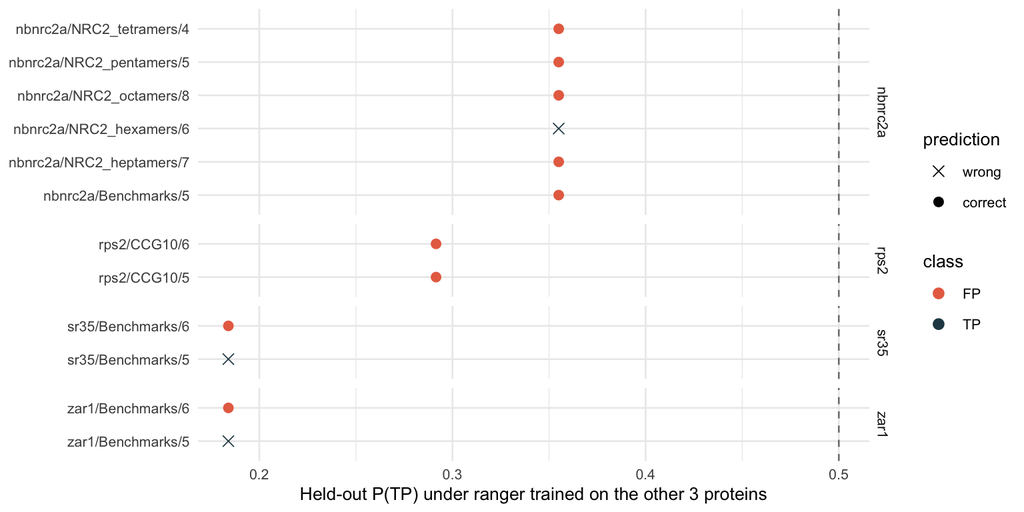

```r
ggplot(lopo_ranger, aes(x = prob_TP, y = row_id,
                        colour = class, shape = correct)) +
  geom_vline(xintercept = 0.5, linetype = "dashed", colour = "grey50") +
  geom_point(size = 2.5) +
  facet_grid(held_out_protein ~ ., scales = "free_y", space = "free_y") +
  scale_colour_manual(values = c(FP = "#e76f51", TP = "#264653")) +
  scale_shape_manual(values = c(`TRUE` = 16, `FALSE` = 4),
                     labels = c(`TRUE` = "correct", `FALSE` = "wrong"),
                     name = "prediction") +
  labs(x = "Held-out P(TP) under ranger trained on the other 3 proteins",
       y = NULL) +
  theme_minimal(base_size = 10)
```

## 4. Reading the result

Two things to take away, in plain terms.

First, **the across-protein picture is at least as bad as 005 said and probably worse.** The LOPO featureless baseline gives 9/12 again, for the same reason as in 005 — FP is the training majority in every fold, so always-predict-FP scores 9/12. The LOPO ranger number sits on top of that baseline or below it, not above it. The features, asked to generalise from three proteins to a fourth, are not finding a reliable signal.

Second, **the RPS2 fold is a free pass for any FP-predictor.** RPS2 contributes only FP rows (GT = octamer, but both deposits are penta/hexa), so predicting FP for the RPS2 fold scores 2/2 without using the features. That gives the aggregate accuracy a roughly +0.17 floor it would not get on a more balanced panel. Any single accuracy number read off the LOPO table should be read with that in mind.

Taken together with 005: the decent-looking `SD_THETA_ROT` AUC on the full 12-row LOOCV was mostly the NbNRC2a stoichiometry sweep talking. When we force the classifier to generalise *across proteins*, that within-protein signal doesn’t carry the task on its own. The honest version of the conclusion is: **we don’t have enough independent proteins yet to tell whether the canonical SNI features separate real from forced-wrong AF3 oligomer calls in general.**

## 5. Decisions / next moves for 007

- Notebook 007 runs a power analysis that makes the sample-size question explicit: given the per-feature effect sizes observed in 005/006, how many independent GT proteins would be needed for a classifier to plausibly beat the null?
- The 12-row GT subset stays as it is; curating more plant-NLR oligomeric-state ground truth is the binding constraint on moving past this, and 007 will try to put a number on how much more.
- No more classifier sweeps on this matrix in isolation — the returns are exhausted until the GT panel widens.